# QC Analysis of ICB Wolf mae

Nasim Bondar Sahebi

UofT, Princess Margaret Cancer Center,University Health Network, Toronto, Ontario, Canada

2024 15 09

## load libraries

```r
library(MultiAssayExperiment)
library(ggplot2)
library(dplyr)
library(tidyr)
library(knitr)
library(DESeq2)
library(pheatmap)
library(gridExtra)
library(edgeR)
```

## Data Loading and Preparation

**Data Overview**:

- **Study Reference**: [PubMed ID 30753825](https://pubmed.ncbi.nlm.nih.gov/30753825/)
- **Patient Count** : 91
- **Treatment counts**:
- **IO+combo**: 41
- **PD-1/PD-L1**: 50

Load multiassay .rds file, extract clinical, expression and annotations data; prepare gene expression data for analysis.

```r
# Load your multiassay result and extract clinical data , expression data and annotation

#load mae obj
mae <- readRDS("~/BHK lab/ICB/ICB_Gide/output/ICB_Gide.rds")

#extract Clinical data
clin <- data.frame(colData(mae)) # Dim 91 x 51

# assay names:  "expr_gene_tpm", "expr_gene_counts", "expr_isoform_tpm", "expr_isoform_counts"
names(mae)
```

```
## [1] "expr_gene_tpm"       "expr_gene_counts"    "expr_isoform_tpm"
## [4] "expr_isoform_counts"
```

```r
#extract the expression data
expr <- assays(mae)[["expr_gene_tpm"]] # Dim 61544 x 91 and range is : -9.965784 to 16.769311

#extracting the annotation
annot <- data.frame(rowData(mae@ExperimentList$expr_gene_tpm))

# Display first few rows of the data set.
DT::datatable(expr[1:8, 1:4])
```

|  | ERR2208887 | ERR2208888 | ERR2208889 | ERR2208890 |
| --- | --- | --- | --- | --- |
| ENSG00000000003.15 | 3.24656570154477 | 3.26906940725837 | 4.65268478528223 | 2.25571243507434 |
| ENSG00000000005.6 | -0.692155002057543 | -2.27733784023983 | 6.6564284994461 | -1.93388238125779 |
| ENSG00000000419.14 | 6.04754620698798 | 5.75322146591736 | 6.94212704074918 | 5.68463210847596 |
| ENSG00000000457.14 | 1.90507289501996 | 1.57894742482549 | 2.9030365480154 | 2.16777841792228 |
| ENSG00000000460.17 | 3.48953937675977 | 3.18540411521774 | 4.30430619779718 | 2.74045435688378 |
| ENSG00000000938.13 | 1.12524319305122 | -0.0230140164882107 | -0.789462747891338 | 3.36048602889927 |
| ENSG00000000971.17 | 7.15950247613522 | 5.87573447183403 | 7.2712380986893 | 6.63037152529624 |
| ENSG00000001036.14 | 3.81855304389382 | 3.43570477525826 | 2.28622815584891 | 3.33305917194872 |

## Quality Control Comparison: Clinicopathologic Characteristics of Anti-PD-1 Monotherapy and Combined Anti-PD-1 with Anti-CTLA-4 Immunotherapy Cohorts

**Objective**: Compare our dataset (91 patients) to the published study (120 patients) for key clinical characteristics and outcomes in Anti-PD-1 Monotherapy and Combined Anti-PD-1 with Anti-CTLA-4 Immunotherapy cohorts.

- **Published Study**: 63 monotherapy, 57 combination therapy patients.
- **Our Data**: 50 monotherapy, 41 combination therapy patients. Slightly fewer patients overall in our data (91 vs. 120).

**Gender Breakdown (Male %)**: - **Published Study**: Monotherapy Non-responders: 67%, Responders: 55%; Combo Therapy Non-responders: 62%, Responders: 66%. - **Our Data**: Monotherapy Non-responders: 73.9%, Responders: 59.3%; Combo Therapy Non-responders: 63.6%, Responders: 66.7%.  
- **Difference**: Gender distribution is highly consistent, with very minor differences.

**Progression-Free Survival (PFS, months)**: - **Published Study**: Monotherapy: 2.6 months for non-responders, Combo Therapy: 2.7 months for non-responders. - **Our Data**: Monotherapy: 2.6 months for non-responders, 29 months for responders; Combo Therapy: 2.7 months for non-responders, 20.1 months for responders.  
- **Difference**: Close alignment, with minor differences in responder data.

The comparison confirms that our dataset aligns well with the published study in terms of clinical characteristics, response rates, and survival outcomes. Minor variations are expected due to cohort size differences, but overall trends are consistent.

```r
# Define responder and non-responder groups based on the criteria
clin$response_paper <- ifelse(
  (clin$recist %in% c("CR", "PR") | (clin$recist == "SD" & clin$survival_time_pfs > 6)),
  "Responder",
  ifelse(clin$recist == "PD" | (clin$recist == "SD" & clin$survival_time_pfs <= 6),
         "Non-responder",
         NA)
)

# Subset data to mono and combo
monotherapy <- clin %>% filter(treatment == "PD-1/PD-L1")
combo_therapy <- clin %>% filter(treatment == "IO+combo")

# Generate summary statistics
generate_detailed_summary <- function(data) {
  data %>%
    group_by(response_paper) %>%
    summarize(
      `Age (years), median` = as.character(round(median(age, na.rm = TRUE), 1)),
      Male = paste0(sum(sex == "M", na.rm = TRUE), " (", round(sum(sex == "M", na.rm = TRUE) / n() * 100, 1), "%)"),
      Female = paste0(sum(sex == "F", na.rm = TRUE), " (", round(sum(sex == "F", na.rm = TRUE) / n() * 100, 1), "%)"),
      `Nivolumab n (%)` = paste0(sum(treatmentid == "Nivolumab", na.rm = TRUE), " (", round(sum(treatmentid == "Nivolumab", na.rm = TRUE) / n() * 100, 1), "%)"),
      `Pembrolizumab n (%)` = paste0(sum(treatmentid == "Pembrolizumab", na.rm = TRUE), " (", round(sum(treatmentid == "Pembrolizumab", na.rm = TRUE) / n() * 100, 1), "%)"),
      CR = as.character(sum(recist == "CR", na.rm = TRUE)),
      PR = as.character(sum(recist == "PR", na.rm = TRUE)),
      SD = as.character(sum(recist == "SD", na.rm = TRUE)),
      PD = as.character(sum(recist == "PD", na.rm = TRUE)),
      `Median PFS (months)` = as.character(round(median(survival_time_pfs, na.rm = TRUE), 1)),
      `12-month PFS (%)` = as.character(round(mean(survival_time_pfs >= 12, na.rm = TRUE) * 100, 1)),
      `Median OS (months)` = as.character(round(median(survival_time_os, na.rm = TRUE), 1)),
      `12-month OS (%)` = as.character(round(mean(survival_time_os >= 12, na.rm = TRUE) * 100, 1))
    )
}

# Generate summaries
monotherapy_summary <- generate_detailed_summary(monotherapy) %>% mutate(Therapy = "Monotherapy")
combo_therapy_summary <- generate_detailed_summary(combo_therapy) %>% mutate(Therapy = "Combination Therapy")

# Combine and reshape
combined_summary <- bind_rows(monotherapy_summary, combo_therapy_summary) %>%
  pivot_longer(cols = -c(Therapy, response_paper), names_to = "Characteristic", values_to = "Value") %>%
  pivot_wider(names_from = c(Therapy, response_paper), values_from = Value)

# Add number of patients to column headers
colnames(combined_summary) <- c("Characteristic",
                                "Monotherapy  Non-responder (n=23)",
                                "Monotherapy Responder (n=27)",
                                "Combination Therapy Non-responder (n=11)",
                                "Combination Therapy Responder (n=30)")

# Define row names
rownames_final <- c("Age (years), median", "Male", "Female",
                    "Nivolumab n (%)", "Pembrolizumab n (%)", "CR", "PR",
                    "SD", "PD", "Median PFS (months)", "12-month PFS (%)",
                    "Median OS (months)", "12-month OS (%)")

rownames(combined_summary) <- rownames_final

# Print table with kable
kable(combined_summary, caption = "Table 1. Clinicopathologic Characteristics of Anti-PD-1 Monotherapy and Combined Anti-PD-1 with Anti-CTLA-4 Immunotherapy
Cohorts", align = "l")
```

Table 1. Clinicopathologic Characteristics of Anti-PD-1 Monotherapy and Combined Anti-PD-1 with Anti-CTLA-4 Immunotherapy Cohorts

| Characteristic | Monotherapy Non-responder (n=23) | Monotherapy Responder (n=27) | Combination Therapy Non-responder (n=11) | Combination Therapy Responder (n=30) |
| --- | --- | --- | --- | --- |
| Age (years), median | 67 | 62 | 51 | 65 |
| Male | 17 (73.9%) | 16 (59.3%) | 7 (63.6%) | 20 (66.7%) |
| Female | 6 (26.1%) | 11 (40.7%) | 4 (36.4%) | 10 (33.3%) |
| Nivolumab n (%) | 5 (21.7%) | 6 (22.2%) | 0 (0%) | 0 (0%) |
| Pembrolizumab n (%) | 18 (78.3%) | 21 (77.8%) | 0 (0%) | 0 (0%) |
| CR | 0 | 4 | 0 | 13 |
| PR | 0 | 19 | 0 | 13 |
| SD | 3 | 4 | 2 | 4 |
| PD | 20 | 0 | 9 | 0 |
| Median PFS (months) | 2.6 | 29 | 2.7 | 20.1 |
| 12-month PFS (%) | 0 | 74.1 | 0 | 80 |
| Median OS (months) | 5.5 | 35.8 | 17.7 | 20.8 |
| 12-month OS (%) | 21.7 | 96.3 | 54.5 | 86.7 |

## Immunotranscriptomic Gene Signatures in Responders and Non-responders to Anti-PD-1 Monotherapy and Combined Anti-PD-1

The paper mentions 47 PRE samples (n = 35 responders, n = 12 non-responders) and 15 EDT samples (n = 11 responders, n = 4 non-responders). In our dataset, we have 41 PRE and 9 POST samples.

### Steps Used for Analysis (Monotherapy

```r
# Access gene expression counts and annotation data
expr_gene_counts <- assays(mae)[["expr_gene_counts"]]
annot <- data.frame(rowData(mae@ExperimentList$expr_gene_counts))

# Remove duplicate genes and set as rownames
annot <- annot[!duplicated(annot$gene_name), ]
annot <- annot[, c("gene_id", "gene_name")]

# Match gene IDs and gene names, and remove rows without a gene name
expr_gene_counts$gene_id <- rownames(expr_gene_counts)
expr_gene_counts <- merge(expr_gene_counts, annot, by = "gene_id")
expr_gene_counts <- expr_gene_counts[!is.na(expr_gene_counts$gene_name), ]
rownames(expr_gene_counts) <- expr_gene_counts$gene_name
expr_gene_counts$gene_id <- NULL
expr_gene_counts$gene_name <- NULL

# Revert log-transformed data (if necessary)
expr_gene_counts <- 2^expr_gene_counts - 1

# Define sample subsets for PRE and POST treatments
pre_samples <- monotherapy$patientid[monotherapy$treatment_time == "PRE"]
post_samples <- monotherapy$patientid[monotherapy$treatment_time == "POST"]

# Ensure sample IDs in monotherapy match column names of expr_gene_counts
pre_samples <- intersect(pre_samples, colnames(expr_gene_counts))
post_samples <- intersect(post_samples, colnames(expr_gene_counts))

# Subset expression data for PRE and POST samples
expr_pre <- expr_gene_counts[, colnames(expr_gene_counts) %in% pre_samples]
expr_post <- expr_gene_counts[, colnames(expr_gene_counts) %in% post_samples]

# Create DESeq2 dataset objects and perform normalization and differential expression analysis
dds_pre <- DESeqDataSetFromMatrix(countData = round(expr_pre), colData = monotherapy[monotherapy$treatment_time == "PRE", , drop=FALSE], design = ~ response_paper)
dds_post <- DESeqDataSetFromMatrix(countData = round(expr_post), colData = monotherapy[monotherapy$treatment_time == "POST", , drop=FALSE], design = ~ response_paper)

dds_pre <- DESeq(dds_pre)
dds_post <- DESeq(dds_post)

res_pre <- results(dds_pre, contrast = c("response_paper", "Responder", "Non-responder"))
res_post <- results(dds_post, contrast = c("response_paper", "Responder", "Non-responder"))

write.csv(res_pre, "~/BHK lab/ICB/ICB_Gide/files/res_pre_monotheapy.csv")
sig_res_pre <- res_pre[!is.na(res_pre$padj) & res_pre$padj < 0.05, ]
cat("Number of DEGs in PRE samples: ", nrow(sig_res_pre), "\n")
```

```
## Number of DEGs in PRE samples:  326
```

```r
DT::datatable(data.frame(sig_res_pre[1:13, 1:6]), caption = "All Significant DEGs (padj < 0.05)")
```

|  | baseMean | log2FoldChange | lfcSE | stat | pvalue | padj |
| --- | --- | --- | --- | --- | --- | --- |
| MYH13 | 248.4725360702612 | 2.046036217351074 | 0.5681720936541442 | 3.601085375721622 | 0.0003168914852433919 | 0.03430500253939513 |
| ZBTB32 | 46.06837440520884 | 1.347838872459834 | 0.3454526675851909 | 3.901660050511688 | 9.553526255116526e-05 | 0.01702487371104099 |
| RUNX3 | 377.7641106014875 | 1.072486411171166 | 0.3114395548191489 | 3.443642256019639 | 0.0005739345715262288 | 0.04924500335934926 |
| SLAMF7 | 1068.030092250631 | 1.659272961296927 | 0.4597978351316479 | 3.608701117137382 | 0.0003077338993110514 | 0.03420398050612378 |
| SH2D2A | 60.31246481363976 | 1.187376684060608 | 0.3291149828539603 | 3.607786779453575 | 0.0003088201117639234 | 0.03420398050612378 |
| EFCAB1 | 13.05015329354895 | -2.790035668021892 | 0.6994549552562997 | -3.988871116081443 | 6.638847762871597e-05 | 0.01400124282094236 |
| USH2A | 395.4500811865353 | 1.993803572730803 | 0.4988054783308057 | 3.997156525631663 | 6.410791297664542e-05 | 0.01400124282094236 |
| SERPINB3 | 268.4997335407314 | -3.390609023645392 | 0.9774835798395504 | -3.46871200046342 | 0.0005229597369739435 | 0.04630025696775678 |
| ATP2C2 | 156.3164875954689 | -1.531154834991715 | 0.4426745339402611 | -3.458872642532322 | 0.0005424413310148356 | 0.04757056467574899 |
| SLC9A3 | 377.0799947250856 | -1.386728219538556 | 0.3923496467781697 | -3.534419441755219 | 0.0004086719897863162 | 0.04044838510549945 |

[output cut: 3 more lines]

```r
sig_res_post <- res_post[!is.na(res_post$padj) & res_post$padj < 0.05, ]

# Compute CPM and log-transform for visualization
cpm_pre <- cpm(DGEList(counts = expr_pre), log = TRUE, prior.count = 1)
cpm_post <- cpm(DGEList(counts = expr_post), log = TRUE, prior.count = 1)

# Subset DEGs
cpm_pre_degs <- cpm_pre[rownames(sig_res_pre), ]
cpm_post_degs <- cpm_post[rownames(sig_res_post), ]


# Generate heatmaps with response annotations
pheatmap_pre <- pheatmap(cpm_pre_degs, cluster_rows = TRUE, cluster_cols = TRUE, show_rownames = TRUE, show_colnames = TRUE, color = colorRampPalette(c("blue", "white", "red"))(50), silent = TRUE, main = "PRE Treatment Heatmap (Monotherapy)")

pheatmap_post <- pheatmap(cpm_post_degs, cluster_rows = TRUE, cluster_cols = TRUE, show_rownames = TRUE, show_colnames = TRUE, color = colorRampPalette(c("blue", "white", "red"))(50), silent = TRUE, main = "POST Treatment Heatmap (Monotherapy)")

pheatmap_pre
```

[figure not shown]

```r
# Arrange heatmaps side by side
#grid.arrange(pheatmap_pre$gtable, pheatmap_post$gtable, ncol = 2, widths = c(0.7, 0.3))
```

## Paper

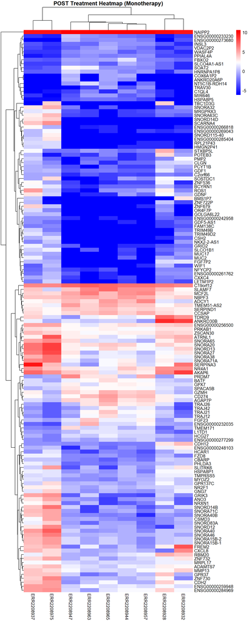

```r
#2.Part d

# diplay post samples
pheatmap_post
```

### FIG 1C: Combination therapy

A similar analysis on the combined anti-CTLA-4 and anti-PD-1 immunotherapy cohort identified 328 DEGs (adjusted p < 0.05) between responders (n = 24 PRE; n = 6 EDT) and non-responders (n = 8 PRE, n = 3 EDT; Figure 1C; Table S5).

We found **135 DEGs** in our combination therapy analysis (adjusted p < 0.05) between responders (n = 24 PRE; n = 6 EDT/POST) and non-responders. The paper identified several key immune-related genes such as **CD8A, CD247, CD5, CD6, and CD69**, as well as genes involved in **NK cell-mediated cytotoxicity** (**CD96**), **T cell cytotoxicity** (**GZMK, CD274 [PD-L1], CD2, ITGAL**), **cytokine signaling** (**CXCL13, CCL4, CCR5, CCL5, CXCL9**), and the **TIGIT/CD226 axis**.

#### Steps for Analysis

1. **Data Processing**: HTSeq version 0.6.1 was used to obtain gene expression read counts.
2. **Normalization**: Read counts were normalized using the `DESeq()` function in DESeq2.
3. **Significance Testing**: Differential gene expression was performed using Wald tests and multiple testing corrections using Benjamini-Hochberg at an FDR of 5%.
4. **Visualization**: Significant DEGs were visualized using CPM and heatmaps, identifying **135 DEGs** with an adjusted p-value < 0.05.

```r
# FIG 1C: Combination therapy

# Access gene expression counts and annotation data
expr_gene_counts <- assays(mae)[["expr_gene_counts"]]
annot <- data.frame(rowData(mae@ExperimentList$expr_gene_counts))

# Remove duplicate genes and set as rownames
annot <- annot[!duplicated(annot$gene_name), ]
annot <- annot[, c("gene_id", "gene_name")]

# Match gene IDs and gene names, and remove rows without a gene name
expr_gene_counts$gene_id <- rownames(expr_gene_counts)
expr_gene_counts <- merge(expr_gene_counts, annot, by = "gene_id")
expr_gene_counts <- expr_gene_counts[!is.na(expr_gene_counts$gene_name), ]
rownames(expr_gene_counts) <- expr_gene_counts$gene_name
expr_gene_counts$gene_id <- NULL
expr_gene_counts$gene_name <- NULL

# Revert log-transformed data (if necessary)
expr_gene_counts <- 2^expr_gene_counts - 1

# Define sample subsets for PRE and POST treatments
pre_samples <- combo_therapy$patientid[combo_therapy$treatment_time == "PRE"]
post_samples <- combo_therapy$patientid[combo_therapy$treatment_time == "POST"]

# Ensure sample IDs in combo_therapy match column names of expr_gene_counts
pre_samples <- intersect(pre_samples, colnames(expr_gene_counts))
post_samples <- intersect(post_samples, colnames(expr_gene_counts))

# Subset expression data for PRE and POST samples
expr_pre <- expr_gene_counts[, colnames(expr_gene_counts) %in% pre_samples]
expr_post <- expr_gene_counts[, colnames(expr_gene_counts) %in% post_samples]

# Filter combo_therapy to include only matching samples for PRE
colData_pre <- combo_therapy[combo_therapy$patientid %in% pre_samples & combo_therapy$treatment_time == "PRE", ]

# Ensure the number of samples (columns in expr_pre) matches the number of rows in colData_pre
expr_pre <- expr_pre[, colnames(expr_pre) %in% colData_pre$patientid]

# Create DESeq2 dataset objects and perform normalization and differential expression analysis
dds_pre <- DESeqDataSetFromMatrix(countData = round(expr_pre), colData = colData_pre, design = ~ response_paper)
dds_post <- DESeqDataSetFromMatrix(countData = round(expr_post), colData = combo_therapy[combo_therapy$treatment_time == "POST", , drop=FALSE], design = ~ response_paper)

dds_pre <- DESeq(dds_pre)
dds_post <- DESeq(dds_post)

res_pre <- results(dds_pre, contrast = c("response_paper", "Responder", "Non-responder"))
res_post <- results(dds_post, contrast = c("response_paper", "Responder", "Non-responder"))

write.csv(res_pre, "~/BHK lab/ICB/ICB_Gide/files/res_pre_combination.csv")

sig_res_pre <- res_pre[!is.na(res_pre$padj) & res_pre$padj < 0.05, ]
cat("Number of DEGs in PRE samples: ", nrow(sig_res_pre), "\n")
```

```
## Number of DEGs in PRE samples:  135
```

```r
DT::datatable(data.frame(sig_res_pre[1:13, 1:6]), caption = "All Significant DEGs (padj < 0.05)")
```

|  | baseMean | log2FoldChange | lfcSE | stat | pvalue | padj |
| --- | --- | --- | --- | --- | --- | --- |
| ETV7 | 210.8265771005379 | 2.292774746428224 | 0.5853350184535437 | 3.917029861780249 | 8.964664774563111e-05 | 0.02932824063589348 |
| BIRC3 | 2727.268456287074 | 2.114849047488716 | 0.5688088758302136 | 3.718031024747912 | 0.000200781616524351 | 0.04092308774592777 |
| SLAMF7 | 1963.710092782731 | 2.418589438145633 | 0.651891995556219 | 3.710107586275853 | 0.00020717118831232 | 0.04178571130935651 |
| WDR37 | 1355.210064725556 | 0.7281223113515737 | 0.1619201155603542 | 4.496799602889198 | 6.898394973668358e-06 | 0.005523802295465961 |
| TNIP3 | 152.667060287211 | 2.099969694893336 | 0.5552477557568778 | 3.782040851350752 | 0.0001555478268476706 | 0.03488778429868906 |
| LY75 | 278.8121707104049 | 2.136937447231796 | 0.5731087597295329 | 3.728676993595911 | 0.0001924876905178338 | 0.04036335337073542 |
| CD84 | 1412.365336636555 | 1.603215961381848 | 0.4159856464513488 | 3.854017500503713 | 0.0001161952843723892 | 0.03199696740403506 |
| ALPK1 | 2009.591237760535 | 1.185624917504509 | 0.2962183631657485 | 4.002536861096265 | 6.266690052448963e-05 | 0.02284693971938611 |
| SMC1B | 468.6409242019892 | -2.262864522854572 | 0.6101336082445586 | -3.708801633408059 | 0.000208242486339849 | 0.04178571130935651 |
| LAMP3 | 590.447281922863 | 2.16211672594104 | 0.555954413825113 | 3.889018006107923 | 0.0001006506510688083 | 0.03065108356371886 |

[output cut: 3 more lines]

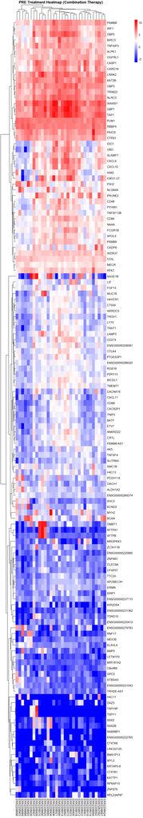

```r
sig_res_post <- res_post[!is.na(res_post$padj) & res_post$padj < 0.05, ]

# Compute CPM and log-transform for visualization
cpm_pre <- cpm(DGEList(counts = expr_pre), log = TRUE, prior.count = 1)
cpm_post <- cpm(DGEList(counts = expr_post), log = TRUE, prior.count = 1)

# Subset DEGs
cpm_pre_degs <- cpm_pre[rownames(sig_res_pre), ]
cpm_post_degs <- cpm_post[rownames(sig_res_post), ]


# Generate heatmaps and store the results
pheatmap_pre_comb <- pheatmap(cpm_pre_degs, cluster_rows = TRUE, cluster_cols = TRUE,
                              show_rownames = TRUE, show_colnames = TRUE,
                              color = colorRampPalette(c("blue", "white", "red"))(50),
                              silent = TRUE, main = "PRE Treatment Heatmap (Combination Therapy)")


pheatmap_pre_comb
```